# Data Analyst Certification - Sample Exam

# Written Report - Used Car Sales

[figure not shown]

[Image source](https://www.istockphoto.com/illustrations/used-car-selling) ("cover_image.jpg")

### This project was done in October, 2025.

This project is from a sample exam for the Data Analyst Certification from DataCamp.

## 📖 Company Background

*Discount Motors* is a used car dealership in the UK. They want to lead the way in used cars. Selling to customers who want the latest and greatest features, without the price tag of a brand new car.

The UK Government has now announced that from 2030 all new cars will be required to be zero emissions. Although this won’t impact the used car market, it is expected that buyers will give more consideration to the future value of their cars. And petrol and diesel will likely have a much lower value after 2030.

## 🚗 UK Used Car Sales

The details in the data reflect the information given to potential buyers in the website adverts.

Buyers typically want to know the road tax of a used car, which varies based on a combination of year registered, emissions and fuel type, with Electric cars currently exempt from road tax.

[figure not shown]

Example of a used car advert from AutoTrader. ("ex_advert.png")

## 💾 The Data

The marketing team has provided some data from the website listings from the last six months. We know that all of the cars in this data sold. I think there is a lot of information missing that could be useful to us. I will let you decide how to process it, just make sure you include all your decisions in your report.  
The data hasn’t been validated, so make sure that you check it against all of the information in the table before you start your analysis.

| Column | Description |
| --- | --- |
| `'model'` | Character, the model of the car, 18 possible values. |
| `'year'` | Numeric, year of registration from 1998 to 2020 (23 year's worth). |
| `'price'` | Numeric, listed value of the car in GBP. Assume the car also sold for this price. |
| `'transmission'` | Character, one of "Manual", "Automatic", "Semi-Auto" or "Other". |
| `'mileage'` | Numeric, listed mileage of the car at time of sale. |
| `'fuelType'` | Character, one of "Petrol", "Hybrid", "Diesel" or "Other". |
| `'tax'` | Numeric, road tax in GBP. Calculated based on CO2 emissions or a fixed price depending on the age of the car. |
| `'mpg'` | Numeric, miles per gallon as reported by manufacturer. |
| `'engineSize'` | Numeric, listed engine size, one of 16 possible values. |

## 📋 Guide to Analysis Projects

[figure not shown]

("email1.png")

[figure not shown]

("email2.png")

In reference to the emails/images above: 1) I would like you to create a written report to summarize the analysis you have performed and your findings. The report will be read by me (Head of Analysis). The list below (see the **Written Report** section) describes what I expect to see in your written report. 2) You will need to use a DataLab workbook to write up your findings and share visualizations. 3) You must use the data provided for the analysis. 4) You will also need to prepare and deliver a presentation. You should prepare around 8-10 slides to present to the sales rep. The list below describes what they expect to see in your presentation (see the **Presentation** section). 5) Your presentation should be no longer than 10 minutes.

## 📓 Written Report

Your written report should include written text summaries and graphics of the following:

- **Data validation**:
  - Describe validation and cleaning steps for every column in the data
- **Exploratory Analysis**:
  - Include two different graphics showing single variables only to demonstrate the characteristics of data
  - Include at least one graphic showing two or more variables to represent the relationship between features
  - Describe your findings
- **Definition of a metric for the business to monitor**
  - How should the business use the metric to monitor the business problem
  - Can you estimate initial value(s) for the metric based on the current data
- **Final summary including recommendations that the business should undertake**

## 💬 Presentation

You will be giving an overview presentation to the sales rep who requested the work. The presentation should include:

- An overview of the project and business goals
- A summary of the work you undertook and how this addresses the problem
- Your key findings including the metric to monitor and current estimation
- Your recommendations to the business

## ✍️ Grading

Before submitting your written report or delivering your presentation, remember to check your work against the grading criteria. You can find the full grading rubric [here](https://app.datacamp.com/certification/get-started/data-analyst/overview#rubric). You must pass all criteria to pass this part of the certification.

## Sample Solution

You can find a sample solution from the published workbook in the directory containing this project and an [accompanying presentation](https://www.loom.com/share/ab4dfa9ca93140d3b0ba42f31a5da065). The sample solution demonstrates one possible approach to the problem given.

#### This notebook will contain the Written Report part of the project. A separate notebook will be made for the Presentation.

Notes on objectives of **Written Report**:

- The data is from the website listings from the last 6 months. All of the cars in the data sold.
- Notes from Email 1 (Head of Analytics):
  - perform analysis, write short report for Head of Analytics
  - they want to read your thinking & how you reached your conclusions
  - prepare & deliver verbal presentation to Marketing Team
- Notes from Email 2:
  - by 2030, company can only sell EV's in UK
  - want to run campaign promoting used EV's
  - in last year, haven't sold any EV's --> want to know about hybrids to help get ideas
    - want to know anything about how the sales differ between hybrids & other types from sales over last 6 months
      - it is unknown when exactly these sales occurred, so I'll just assume they are from the last 6 months from when I am doing this report (Sept, 2025)
    - there are less hybrid cars for sale. Company "thinks they are more expensive, so we need to make them more appealing."
    - "We think hybrid could be a good way to get buyers to think about more environmentally friendly cars."
  - goal is to increase the # sales of hybrid & electric cars next year
  - want to start campaigning ASAP to beat competitors

From **Written Report** section above: Your written report should include written text summaries and graphics of the following:

- **Data validation**
  - Describe validation and cleaning steps for every column in the data
- **Exploratory Analysis**
  - Include two different graphics showing single variables only to demonstrate the characteristics of data
  - Include at least one graphic showing two or more variables to represent the relationship between features
  - Describe your findings
- **Definition of a metric for the business to monitor**
  - How should the business use the metric to monitor the business problem
  - Can you estimate initial value(s) for the metric based on the current data
- **Final summary including recommendations that the business should undertake**

### Plan of Action

1) Data Validation 2) EDA 3) Definition of a metric for the business to monitor 4) Final summary including recommendations that the business should undertake

### Importing modules

```python
import pandas as pd
import numpy as np
import statistics
import itertools

import matplotlib.pyplot as plt
import seaborn as sns
import plotly.express as px
from plotly.subplots import make_subplots
import plotly.graph_objects as go
import geopandas as gpd
```

# Part I - Data Validation

**Describe validation & cleaning steps for every column in the data.**

This section will encompass the typical steps in the beginning of an analytical project. Mainly, importing the data, inspecting it, validating it, cleaning it (if necessary), & making other adjustments so that it is ready for analysis.

```python
#Import the dataset
orig_df = pd.read_csv('toyota.csv')

#Inspect the dataset
#display(orig_df.sample(n=5, random_state=10))
display(orig_df.info())

#Investigate values in each variable
display(orig_df['model'].value_counts(dropna=False).sort_index().reset_index())
```

```
<class 'pandas.core.frame.DataFrame'>
RangeIndex: 6738 entries, 0 to 6737
Data columns (total 9 columns):
 #   Column        Non-Null Count  Dtype
---  ------        --------------  -----
 0   model         6738 non-null   object
 1   year          6738 non-null   int64
 2   price         6738 non-null   int64
 3   transmission  6738 non-null   object
 4   mileage       6738 non-null   int64
 5   fuelType      6738 non-null   object
 6   tax           6738 non-null   int64
 7   mpg           6738 non-null   float64
 8   engineSize    6738 non-null   float64
dtypes: float64(2), int64(4), object(3)
memory usage: 473.9+ KB
```

```
None
```

|  | model | count |
| --- | --- | --- |
| 0 | Auris | 712 |
| 1 | Avensis | 115 |
| 2 | Aygo | 1961 |
| 3 | C-HR | 479 |
| 4 | Camry | 11 |
| 5 | Corolla | 267 |
| 6 | GT86 | 73 |
| 7 | Hilux | 86 |
| 8 | IQ | 8 |
| 9 | Land Cruiser | 51 |
| 10 | PROACE VERSO | 15 |
| 11 | Prius | 232 |
| 12 | RAV4 | 473 |
| 13 | Supra | 12 |
| 14 | Urban Cruiser | 4 |
| 15 | Verso | 114 |
| 16 | Verso-S | 3 |
| 17 | Yaris | 2122 |

In the original dataset, there are 6,738 observations & nine variables. There are no missing values. The data types seem appropriate for each variable. Upon inspecting the values of each variable, there are no strange or inconsistent values that seem out of place. Details pertaining to each variable are listed below.

Another step in the data validation process often involves checking for duplicate observations that do not belong or are unnecessary. Given the nature of the dataset, it is probable that there are duplicates data points. More specifically, it is not unlikely that the same exact car made in the same year, with the same transmission, with the same engine size, listed at the same price, with the same mileage, et cetera is listed by the company, indicating that more than one such car is available. Such instances are not duplicate observations that need to be removed unless indicated directly.

```python
#Check for duplicate observations
display(orig_df[orig_df.duplicated(keep=False)].sort_values(orig_df.columns.tolist())[30:40])

#Rename dataset
df = orig_df.copy()
```

|  | model | year | price | transmission | mileage | fuelType | tax | mpg | engineSize |
| --- | --- | --- | --- | --- | --- | --- | --- | --- | --- |
| 5342 | Aygo | 2019 | 9999 | Manual | 20 | Petrol | 145 | 57.7 | 1.0 |
| 4511 | Aygo | 2019 | 9999 | Manual | 1500 | Petrol | 145 | 56.5 | 1.0 |
| 4516 | Aygo | 2019 | 9999 | Manual | 1500 | Petrol | 145 | 56.5 | 1.0 |
| 4517 | Aygo | 2019 | 9999 | Manual | 1500 | Petrol | 145 | 56.5 | 1.0 |
| 5490 | Aygo | 2019 | 10000 | Manual | 150 | Petrol | 145 | 57.7 | 1.0 |
| 5493 | Aygo | 2019 | 10000 | Manual | 150 | Petrol | 145 | 57.7 | 1.0 |
| 3901 | Aygo | 2019 | 10000 | Manual | 1000 | Petrol | 145 | 57.7 | 1.0 |
| 3902 | Aygo | 2019 | 10000 | Manual | 1000 | Petrol | 145 | 57.7 | 1.0 |
| 5487 | Aygo | 2019 | 10350 | Manual | 2000 | Petrol | 145 | 57.7 | 1.0 |
| 5488 | Aygo | 2019 | 10350 | Manual | 2000 | Petrol | 145 | 57.7 | 1.0 |

Upon investigating the dataset for duplicate values, some did exist, but there is no reason to think that each such duplicate listing is not supposed to be present. There are no more than three "duplicate" cars listed in the dataset. In other words, no identical observation was listed more than three times in the dataset.

At this point, the data has been thoroughly inspected, validated, & no data cleaning is necessary.

# Part II - Exploratory Data Analysis

- Include two different graphics showing single variables only to demonstrate the characteristics of data.
- Include at least one graphic showing two or more variables to represent the relationship between features.
- Describe your findings.

*Discount Motors* has expressed interest in learning how to make hybrid cars more appealing to customers. By evaluating the characteristics of hybrid & non-hybrid cars that the company has sold over the last six months, it could help provide them information necessary to make optimal changes to their marketing techniques for the coming years.

To start, it might be useful to get an understanding of what types of cars *Discount Motors* has recently relied on for sales because it could provide an evaluation of how ready the company may or may not be to sell more hybrid & electric vehicles which are expected to be more valuable as a result of the UK's new mandate regarding car emissions. If the company currently sells significantly more diesel & petrol vehicles than hybrid & electric vehicles, then the company might find the transition more challenging. If they have recently been selling a greater proportion of hybrid & electric vehicles than others, then this transition will probably be smoother.

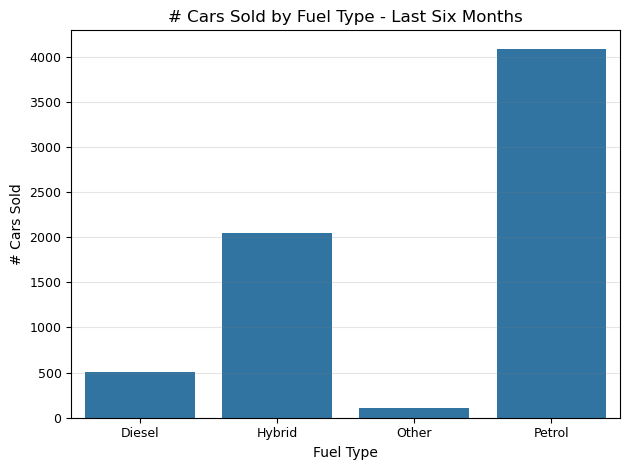

```python
#Make a figure indicating the # cars sold based on 'fuelType'
ax1 = sns.countplot(data=df.sort_values('fuelType'), x='fuelType')

#edit plot details
plt.title('# Cars Sold by Fuel Type - Last Six Months')
plt.xlabel('Fuel Type')
plt.xticks(fontsize=9)
plt.ylabel('# Cars Sold')
plt.yticks(fontsize=9)
plt.grid(axis='y',alpha=0.2,color='gray')
plt.tight_layout();
```

The bar plot above illustrates the number of cars sold by *Discount Motors* over the last six months according to their fuel type. In total, the company has sold 6,738 cars during this time period. It is assumed that electric vehicles correspond to the "Other" fuel-type category.

This figure helps to establish an impression of how much of a shift the company could experience in terms of what types of cars they promote & sell as a result of the UK's mandate regarding new cars having zero emissions come 2030. Even though used cars that produce emissions will still be street legal in the UK, they will become considerably less valuable compared to electric & hybrid vehicles as a result of this change.  
Based on this plot:

- About two-thirds of the cars sold by *Discount Motors* in the last six months have been diesel & petrol vehicles.
  - These types of cars are expected to be valued the least come 2030, so the company might expect to sell less of these cars once the requirement officially goes into effect.
- *Discount Motors* have sold no more than 105 electric vehicles in the last six months. On the other hand, the company has been fairly proficient in selling hybrid cars recently--they account for approximately 30% of their total number of sold cars in the last half year.

Generally, *Discount Motors* has sold slightly about 2.1 diesel/petrol vehicles for every hybrid/"Other" vehicle sold between in the last six months. If hybrid & electric vehicles become more valuable than diesel & petrol vehicles come 2030, then it's possible that this trend reverses completely. Based on this data from the last six months, this could be a stark change for the company to undergo.

- While there are generally less hybrid cars available for sale than diesel/petrol cars, as long as the company ends up selling more hybrid/electric cars & less diesel/petrol cars in the period leading up to 2030, then they will probably have a more seamless transition once the UK's legislation officially goes into effect.

In the emails provided, the Marketing Team has expressed that "our goal is to increase the number of sales of hybrid & electric cars next year." Moreover, they are interested in "how the sales differ between hybrids & other types over the last six months." To be prepared to evaluate this question, an understanding of prices at which cars were sold by this company recently would be helpful.

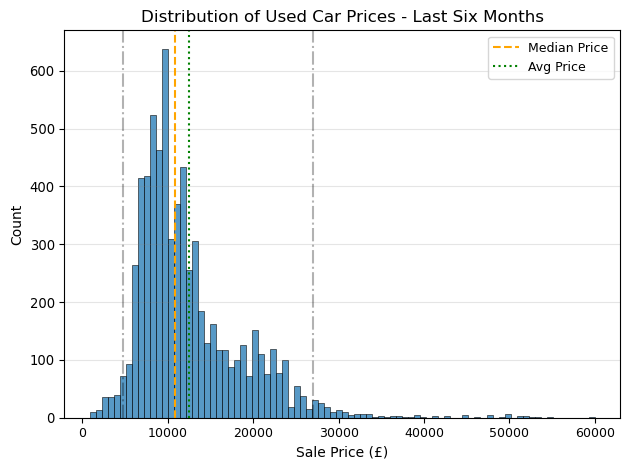

```python
#Make a histogram of used-car prices
ax = sns.histplot(data=df, x='price')

#add median price
plt.axvline(df['price'].median(), color='orange', linestyle='--', alpha=1, label='Median Price')
#add mean price
plt.axvline(df['price'].mean(), color='green', linestyle=':', alpha=1, label='Avg Price')
#add confidence intervals (95%)
plt.axvline(np.percentile(df['price'], 2.5), color='black', linestyle='-.', alpha=0.3)
plt.axvline(np.percentile(df['price'], 97.5), color='black', linestyle='-.', alpha=0.3)

#edit plot details
plt.title('Distribution of Used Car Prices - Last Six Months')
plt.xlabel('Sale Price (£)')
plt.xticks(fontsize=9)
plt.yticks(fontsize=9.5)
plt.legend(fontsize=9)
plt.grid(axis='y',alpha=0.2,color='gray')
plt.tight_layout();
```

The figure above illustrates the distribution of prices at which used cars were sold by the company *Discount Motors* in the last six months. The vertical, orange, dashed line indicates the median sale price, whereas the vertical, green, dotted line indicates the average sale price. The two vertical, black, dash-dot lines indicate the confidence intervals of the distribution, which include 95% of the data points. During this time frame, the company has sold 6,738 used cars. Note that the sale prices are in units of British pounds (£).

In the last half year, *Discount Motors* has sold used cars at prices between about £1,000 - £60,000. The majority of these cars were sold at somewhere between about £5,000 - £27,000. This lattermost range can be considered as what a typical customer might be willing to spend on a used car.  
Typically, the company sold cars at around £11,000. The distribution peaked at a sales price of about £10,000; however, the distribution is slightly skewed to the right, indicating that some cars were sold at a significantly high price relatively speaking. This resulted in an average price that was larger than the median price, as demonstrated by the green & orange lines.

Moreover, more cheap cars were sold by *Discount Motors* than expensive ones. From the previous bar plot, which illustrated the number of used cars sold by fuel type, it was found that the company sold more petrol cars than hybrid & electric cars. If the former are cheaper, then it would be logical to conclude that if the company sold more hybrid & electric cars & fewer diesel & petrol cars, as is likely to be the case come 2030, than the typical price of their used cars will likely be higher than what is observed in this distribution above.

- More specifically, the median price of used cars that *Discount Motors* sold during this time period was about £10,800. If the majority of the cars they sell were to change to a more expensive type (as electric cars are theorized to be), then the typical price of the company's used cars would increase from this price.

Now that some of the most relevant variables have been evaluated, they, along with others, can be analyzed in relation to one another. To expand on earlier analyses, an illustration of prices of used cars based on when they were made as well as their fuel type can help to understand how different types of cars have been valued as of recently.

With the data being split by the registration 'year' & 'fuelType' variables, it might also be important to retrieve the number of data points in each group. Recall that the dataset has about 6,740 total observations, so pairs of values across two variables with 23 & four unique values respectively might have a very small number of corresponding data points. Such small groups may not be helpful because one extremely small or large price can heavily influence that group's data.

```python
#Compute # data points per 'fuelType' each registration 'year'
yr_ft_num = df.groupby(['year','fuelType'])['price'].count().reset_index().rename(columns={'price':'# data points'})

#Compute average 'price' per 'fuelType' each registration 'year'
yr_ft_pr = df.groupby(['year','fuelType'])['price'].mean().reset_index().rename(columns={'price':'Avg price'})

#Join the datasets above
yr_ft_pr_metrics = yr_ft_num.merge(yr_ft_pr, on=['year','fuelType'])

#Inspect the results
display(yr_ft_pr_metrics.sort_values('# data points', ascending=True).head(20))
```

|  | year | fuelType | # data points | Avg price |
| --- | --- | --- | --- | --- |
| 0 | 1998 | Diesel | 1 | 19990.000000 |
| 1 | 1999 | Petrol | 1 | 1995.000000 |
| 2 | 2000 | Petrol | 1 | 2695.000000 |
| 3 | 2001 | Petrol | 1 | 899.000000 |
| 35 | 2013 | Other | 1 | 17995.000000 |
| 5 | 2003 | Diesel | 1 | 850.000000 |
| 18 | 2008 | Other | 1 | 4995.000000 |
| 10 | 2005 | Hybrid | 1 | 2495.000000 |
| 28 | 2011 | Other | 2 | 6872.500000 |
| 7 | 2004 | Diesel | 2 | 6212.500000 |
| 17 | 2008 | Hybrid | 2 | 4242.500000 |
| 23 | 2010 | Diesel | 3 | 5413.333333 |
| 16 | 2008 | Diesel | 3 | 4513.333333 |
| 14 | 2007 | Diesel | 3 | 3893.666667 |
| 39 | 2014 | Other | 3 | 9526.666667 |
| 9 | 2005 | Diesel | 4 | 4421.250000 |
| 21 | 2009 | Hybrid | 4 | 6522.500000 |
| 4 | 2002 | Petrol | 4 | 1811.000000 |
| 27 | 2011 | Hybrid | 4 | 7935.000000 |
| 8 | 2004 | Petrol | 5 | 2966.000000 |

Ultimately, the dataset compiled above can be filtered to exclude data points with a very small number of data points that might not be representative. Conversely, it is possible that each data point has value in its own right. Nevertheless, extreme values may need to be referenced to determine how representative they truly are. The dataset that has been compiled (see the `yr_ft_pr_metrics` variable) can provide such information.

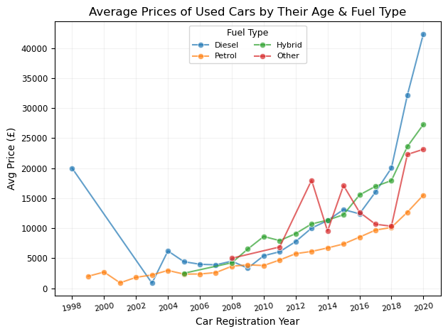

```python
#Build a plot displaying average 'price' of used cars based on their registration 'year' & 'fuelType'
ax = sns.lineplot(data=yr_ft_pr_metrics, x='year', y='Avg price', hue='fuelType', marker='o', alpha=0.7)

#edit plot details
plt.title('Average Prices of Used Cars by Their Age & Fuel Type')
plt.xlabel('Car Registration Year')
plt.xticks(ticks=range(1998,2021,2), fontsize=8, rotation=10)
plt.ylabel('Avg Price (£)')
plt.yticks(ticks=range(0,40001,5000), fontsize=8.5)
plt.legend(loc='upper center', title='Fuel Type', title_fontsize=9, fontsize=8, ncols=2)
plt.grid(axis='both',alpha=0.1,color='gray')
plt.tight_layout();

#save the figure
plt.savefig('FT_avg_pr_age.png')
```

The line plot above illustrates the average prices of used cars sold by *Discount Motors* over the last six months according to their age & fuel type. The data spans cars registered in 1998 to 2020. Note that some fuel-type-model-year pairs did not have any used cars sold which can be seen by straight lines between points that span more than one year (e.g. diesel vehicles in 1999-2002). Note that the vertical axis is in units of British pounds (£). It is assumed that electric vehicles correspond to the "Other" fuel-type group.  
Recall that *Discount Motors* has mostly sold petrol & hybrid vehicles in the last six months. They only sold about 500 diesel & 100 "Other" fuel-type vehicles during this time period. As such, it is more likely that these types exhibit more extreme values.

With this line plot, a multitude of details can be revealed. To start, the typical ages of hybrid & electric vehicles that the company has sold are considerably younger than diesel & petrol vehicles. This is probably due to evolving technology in the automotive industry that has more recently allowed hybrid & electric vehicles to become safer, more reliable, & more affordable. Moreover, it has probably been more difficult for the company to get their hands on such cars as opposed to used diesel & petrol vehicles. As such, it is likely that typical hybrid & electric cars offered by *Discount Motors* are more expensive because they are younger than their diesel & petrol counterparts.

Looking at the picture as a whole, if the (relatively) high data point from 1998 was excluded, there is an unquestionable, increasing trend in average prices of used cars sold by *Discount Motors* based on when they were produced. Generally, this trend is present regardless of the fuel type. There are some osciallations in average prices in some groups on a year-to-year basis, but the average selling price of all four groups is significantly greater for cars made in 2020 than cars made in the early 2000's.

Recall that the marketing team is keenly interested in differences between used hybrid & electric vehicles that they've sold over the last six months. As cars become older, the average price of hybrid vehicles has decreased fairly linearly in the past 10-12 years or so. For electric vehicles, their average price has also generally decreased with age, but they are noticeably more volatile. In fact, of used cars sold by *Discount Motors*, the average price of electric cars registered in 2013 was higher than it was in 2018.  
If these trends continue in the coming years, the marketing team can optimize their selling of them by the following.

- For hybrid cars, the company could emphasize to customers that such cars are very likely to be more expensive the newer they are. So, for interested customers, it would be better to advertise hybrids that are a few years older if affordability is a primary factor.
- For electric cars, the company could emphasize to customers that their prices are more usually more volatile & less predictable based on their age. Electric cars are still fairly new to the automotive industry & the public, so they may be more likely to perform less capably or experience more problems than more established vehicles like hybrids. While customers may be more likely to find an older, used EV that is cheaper than a newer one, there are opportunities for the company to persuade customers to look at newer models because of the unpredictable nature surrounding them. Newer models may be significantly more adaptable & reliable than EV's a few years older, so this intrinsic value may be worth attempting to persuade customers to invest a little more money into them.

In summary, the overall trend painted by the line plot above suggests that prices of all used cars will continue to increase at an impressive rate in the immediate future, particularly the younger that they are. If the UK's mandate regarding new cars having zero emissions in 2030 & beyond is expected to raise the value of buyers' cars, then it is reasonable to think that hybrid & electric cars will never be as cheap as they are currently. As such, the sooner one buys such a car, the more likely it is that they end up spending less on it overall.

With trends regarding prices of used hybrid, electric, & other types of cars now realized, more variables can be analyzed in relation to the different types of used cars according to their fuel type. These other variables could include cars' mileages, road taxes, & fuel consumption/effiency levels (miles per gallon).  
Theoretically, a typical customer looking to effectively spend their money on a used car would probably look for those with a lower mileage, a lower road tax, & a lower fuel consumption rate (high efficiency) because it might ultimately cost them less over time than other cars. Therefore, further analyses could explore these variables & evaluate whether hybrid & electric vehicles sold by *Discount Motors* are more appealing to such customers rather than diesel or petrol cars.

From the information provided, a car's road tax in the UK is based on its emissions &/or its age. Therefore, it would follow that hybrid & electric vehicles would see a lower road tax than their diesel/petrol counterparts because they produce less emissions than the latter types of cars. On the other hand, hybrids & EV's are more likely to be newer than cars that run on diesel or petrol fuels because they have only recently become more popular with the introduction & integration of necessary technologies in the automotive industry.  
By analyzing recent sales data of *Discount Motors*, it can be determined whether the road taxes of hybrids & EV's are more beneficial monetarily for potential customers as opposed to cars that produce more emissions.

To evaluate this query visually, box plots can be used to illustrate the distributions of used cars' road tax data based on their fuel type.

```python
#Make a box plot of used cars' road taxes per 'fuelType'
fig = px.box(df.sort_values('fuelType'), x='fuelType', y='tax')

#edit plot details
fig.update_layout(title='Road Taxes of Used Cars by Fuel Type', xaxis_title='Fuel Type', yaxis_title='Road Tax (£)',
                 yaxis=dict(range=[-10,600]))
fig.show()

#save the figure
fig.write_html("FT_road_tax_boxes.html")
```

[interactive chart not shown]

The figure above illustrates the distribution of road taxes of used cars based on their fuel type that have been sold by *Discount Motors* in the last six months. In this time period, the company has sold 6,738 used cars. A car's road tax, which is in units of British pounds (£), is based on its emissions &/or its age. It is assumed that electric vehicles lie within the "Other" fuel type group.

From this plot, it is fair to state that cars that run on diesel fuel see the widest range of road taxes & hence the greatest road taxes. While the range of values of these types of cars are the least similar to that of the other three groups, the typical road tax of diesel-ran cars is very similar to that of "Other" (electric) & petrol-fuelled cars. The median road tax of these three groups respectively is £145, £140, & £145. So, road taxes of electric vehicles aren't too dissimilar from these other two fuel types that aren't as environmentally friendly.

When it comes to used hybrid vehicles sold by *Discount Motors*, the range of their road taxes are quite comparable to those of electric & petrol vehicles albeit a little thinner & more predictable. On the other hand, the typical road tax of these used hybrid vehicles (**£20**) is *significantly* smaller than that of the other three groups. Moreover, this value isn't fluky because hybrids account for the second largest group of used cars that *Discount Motors* has sold in the last six months. As such, this disparity in typical road taxes between hybrids & non-hybrids is a massive selling point that the marketing team should take advantage of.

It will be important for the company to continue to track this metric in the coming years because the closer the gap between the typical road tax of their used hybrids & non-hybrids, the weaker this selling point becomes. As a result, it could become more difficult for them to sell more hybrids.  
When it comes to electric vehicles, their road taxes should also be tracked because it is possible that they may soon begin to decline. Since they do not produce any emissions that would be "taxable," that is one less variable that could influence their road-tax value. This is an advantage that diesel & petrol vehicles do not have. As such, if this metric does decline for electric vehicles in the coming years, then it could result in an increase in customers that are interested in buying them; however, this advantage might not be as relevant in the immediate future based on the data from the plot above (hybrid road taxes are definitely still preferable than for EV's).  
Nonetheless, there is definitely more optimism that road taxes of EV's will decrease in the near future than there is for diesel & petrol vehicles, which is another selling point that the company could use to increase interest in EV's.

- Ultimately, as soon as the company notices a considerable decline in this metric for EV's, assuming that it happens, it would be wise to jump on it by telling customers about it.

In summary,

- The road taxes of used hybrid vehicles offer a significant advantage to customers over other fuel-type groups on offer.
- While road taxes for electric vehicles have not yet declined to an optimal level, there is more optimism surrounding them in that this metric might decline soon & offer more appeal to customers.

To wrap up this section, a final piece of analysis can do the trick. One key detail when differentiating between hybrid & electric vehicles against others involves their fuel efficiency which is quantified by the 'mpg' variable. Given that hybrid & electric vehicles rely on clean energy & less on non-renewable energy--what diesel- & petrol-engined cars use--it is reasonable to think that they will experience more efficient fuel consumption metrics. In other words, hybrid & electric vehicles seem more likely to have higher 'mpg' values.

To examine this hypothesis, box plots can be produced to compare fuel consumption distributions based on cars' fuel types. On another note, the marketing team has expressed that they want to use the most recent data available; however, comparing such data to older data can provide valuable insights as to how a variable has evolved recently. This idea can be quantified using the 'year' variable which indicates what year a car was registered.  
As such, two figures were produced below. The first illustrates fuel consumption/efficiency levels of used cars registered between 1998 & 2017, whereas the second examines used cars registered from 2018 through 2020. There are some interesting findings that the marketing team could find valuable. By separating the data into these groups, it can provide the company relevant information regarding differences between the youngest cars that they've sold in the past six months & the rest.

Before making the plots, it would be useful to check how many cars were sold by *Discount Motors* based on their fuel type & the time period in which they were registered.

```python
#Retrieve the # cars sold per 'fuelType' in each of the two registration periods
#registered before 2018
num_FT_98_17 = df[df['year'] < 2018].groupby('fuelType')['model'].count().reset_index().rename(columns={'model':'# sold cars'})
#registered after 2017
num_FT_18_20 = df[df['year'] > 2017].groupby('fuelType')['model'].count().reset_index().rename(columns={'model':'# sold cars'})

#Add a variable indicating the registration period
num_FT_98_17['period'] = '1998-2017'
num_FT_18_20['period'] = '2018-2020'

#Combine the data
num_FT_p1 = pd.concat([num_FT_98_17, num_FT_18_20], axis=0).sort_values(['period','fuelType']).reset_index(drop=True)
num_FT_p1
```

|  | fuelType | # sold cars | period |
| --- | --- | --- | --- |
| 0 | Diesel | 401 | 1998-2017 |
| 1 | Hybrid | 1383 | 1998-2017 |
| 2 | Other | 69 | 1998-2017 |
| 3 | Petrol | 2456 | 1998-2017 |
| 4 | Diesel | 102 | 2018-2020 |
| 5 | Hybrid | 660 | 2018-2020 |
| 6 | Other | 36 | 2018-2020 |
| 7 | Petrol | 1631 | 2018-2020 |

From this data, the ranks of the number of used cars that *Discount Motors* has sold by fuel type is in the same order across the two registration periods. In other words, the company sold more petrol cars & fewer "Other"-type cars in both registration periods. Hybrids were their second most popular type of car sold.

Recall that a goal of the company was to sell more hybrid & electric vehicles in the coming years. In the last six months, *Discount Motors* has sold about nearly half the number of hybrids & "Other" cars (presumably electric vehicles) registered between 2018 & 2020 as they did in the 20-year registration period before then; 1998-2017. This indicates that:

- The company has done a good job in selling more younger hybrid & electric vehicles in the last six months, &
- The automotive market has been valuing younger hybrid & electric vehicles more than older cars.

```python
#Make 2 figures of box plots visualizing the distributions of fuel consumption/efficiency per fuel type.
    #In the first plot, use cars registered prior to 2018 (1998-2017).
    #In the second plot, use cars registered within the last 3 years (2018-2020).

#Construct the figure
fig = make_subplots(rows=1, cols=2, shared_yaxes=True, subplot_titles=['Registered in 1998-2017','Registered in 2018-2020'])

#1998-2017
df_98_17 = df[df['year'] < 2018].sort_values('fuelType')
#add plot to the subplot figure
fig.add_trace(go.Box(x=df_98_17['fuelType'], y=df_98_17['mpg']),
              row=1, col=1)
#2018-2020
df_last3_yr = df[df['year'] > 2017].sort_values('fuelType')
fig.add_trace(go.Box(x=df_last3_yr['fuelType'], y=df_last3_yr['mpg']), row=1, col=2)

#edit plot details
fig.update_xaxes(title='Fuel Type', row=1, col=1)
fig.update_xaxes(title='Fuel Type', row=1, col=2)
fig.update_yaxes(title='Fuel Efficiency (miles/gallon)', tickvals=[*range(0,226,25)])
fig.update_layout(title_text='Fuel Efficiencies of Used Cars by Fuel Type - Discount Motors', showlegend=False)
fig.show()

#save the figure
fig.write_html("FT_fuel_eff_boxes.html")
```

[interactive chart not shown]

The plots above illustrate fuel consumptions & efficiencies of used cars sold by *Discount Motors* according to their fuel type. The plot on the left pertains to sales of cars registered between 1998 & 2017, whereas the right plot pertains to cars registered between 2018 & 2020--the last three years of data available. The vertical axis is in units of miles per gallon. Recall that most of the cars sold by the company based on their fuel type are, in order from most to least: petrol, hybrid, diesel, & "Other" (which presumably accounts for electric vehicles).

In both plots above, it is fairly indicative that cars which run on diesel fuels exhibited the lowest fuel efficiency metric. In other words, such cars typically travel the least distance before having to refuel compared to the other three groups of cars. Furthermore, cars that run on petrol fuels exhibited the second lowest fuel efficiency metric, whereas hybrids typically achieved the most efficient fuel consumption levels.  
More specifically, of cars sold that are registered from 2018 onwards, the four groups of cars pictured above had a typical fuel consumption of:

- Used hybrids - 74.3 mpg,
- Used "Other" (electric) cars - 58.3 mpg,
- Used petrol cars - 56.5 mpg
- Used diesel cars - 36.2 mpg

This is the first point that the marketing team could emphasize in their future promotions of hybrid & electric vehicles, particularly the former.

With these two plots, the next step involves comparing them directly. The median values of each fuel-type group in each of the two time registration periods are listed below:

- The typical fuel consumption of **diesel**-powered cars registered between 1998-2017 is about 40% greater than that of cars registered between 2018-2020; 60.1 & 36.2 mpg respectively.
- The typical fuel consumption of **petrol**-powered cars registered between 1998-2017 is about 6.0% greater than that of cars registered between 2018-2020; 60.1 & 56.5 mpg respectively.
- The typical fuel consumption of **hybrid** cars registered between 1998-2017 is about 2.6% greater than that of cars registered between 2018-2020; 76.3 & 74.3 mpg respectively.
- The typical fuel consumption of **"Other"**-powered cars registered between 1998-2017 is about 13% greater than that of cars registered between 2018-2020; 67.3 & 58.3 mpg respectively.

This data illustrates that even though the typical fuel efficiency declined across the two registration periods regardless of fuel type, the miles per gallon of used hybrid vehicles declined the least by a noticeable margin. Cars that run on petrol also saw a relatively small decline in typical fuel efficiency between the two periods, but these cars sold by *Discount Motors* exhibit a fuel efficiency metric (in both registration periods) that is about 25% less than that of hybrid vehicles.

> To summarize these data points, used hybrid vehicles that *Discount Motors* has sold have:  
> A) exhibited the greatest fuel efficiency values of the four fuel groups, especially in cars registered more recently, &  
> B) experienced the smallest decline in fuel efficiency values of the four fuel groups between the 1998-2017 & 2018-2020 registration periods.

As such, the marketing team can point to the incredibly valuable fuel efficiency of hybrids outright as well as to how stable these values have been between younger & older models compared to cars reliant on different forms of energy.

When it comes to electric vehicles sold by *Discount Motors*, their fuel efficiency metrics are relatively competitive amongst the four groups of cars being analyzed; however, there is a notable falloff in fuel efficiency in comparison to hybrid vehicles, particularly in cars that have been registered more recently. Nonetheless, they are still a better alternative in this metric compared to cars that run on diesel & petrol fuels.

## Part II - Conclusions

This section explored multiple variables in the used-cars dataset to evaluate their distributions & relationships. Given that a key interest in this data revolved around fuel types of cars, the number of cars sold by *Discount Motors* across the 'fuelType' variable were visualized.

- The company mostly sold petrol & hybrid cars. Electric cars accounted for the least of their sales in terms of numbers of sold cars.

The prices at which the company used sold cars registered between 1998 & 2020 were visualized to see how they were distributed.

- Typically, the company sold cars at around £11,000. The majority of these cars were sold at somewhere between about £5,000 - £27,000 which can be considered as what a typical customer might be willing to spend on a used car.

Next, a few visuals were constructed to explore the relationships between different variables. One piece of analysis evaluated yearly trends of average selling prices across the four fuel-type groups.

- The overall trend suggested that prices of all used cars will be greater the more recently that they have been registered. If the UK's mandate regarding new cars having zero emissions in 2030 & beyond is expected to raise the value of buyers' cars, then it is reasonable to think that hybrid & electric cars will never be as cheap as they are currently. As such, the sooner one buys such a car, the more likely it is that they end up spending less on it overall.
- For hybrid cars, the company could emphasize to customers that such cars are very likely to be more expensive the newer they are. So, for interested customers, it would be better to advertise hybrids that are a few years older if affordability is a primary factor.
- For electric cars, the company could emphasize to customers that their prices are more usually more volatile & less predictable based on their age compared to hybrids. While customers may be more likely to find an older, used EV that is cheaper than a newer one, there are opportunities for the company to persuade customers to look at newer models because of the unpredictable nature surrounding them. Newer models may be significantly more adaptable & reliable than EV's a few years older, so this intrinsic value may be worth attempting to persuade customers to invest a little more money into them.

Road taxes of used cars across the four fuel types were also examined.

- Typically, hybrid vehicles had a significantly smaller road tax compared to electric & petrol-fuelled vehicles.
- While road taxes for electric vehicles have not yet declined to an optimal level, there is more optimism surrounding them, compared to diesel- & petrol-run cars, in that this metric might decline soon & offer more appeal to customers.

Fuel consumption & efficiency levels were analyzed across the four fuel types in two different registration periods; 1998-2017 & 2018-2020.

- The typical fuel efficiency level decreased between the older & younger generations across all four of the subgroups; however, this decrease was the smallest (by a sizable margin) for used hybrid vehicles.
- Also, hybrid vehicles saw the greatest fuel efficiency in both registration periods across the four subgroups. So, the fuel efficiency of hybrid vehicles is the most optimistic for the immediate future.
- Electric vehicles have relatively competitive values in this metric, but they are a clear step behind compared to hybrids.

In summary, hybrid vehicles sold by *Discount Motors* are more appealing to used-car customers because:

- Their average prices have been more stable than electric vehicles for cars registered more recently. Used EV's have shown to be more prone to unpredictable shifts in prices, so by the time a customer comes to purchase an EV, it may have already increased in price by more than what they anticipated. Hybrid vehicles have shown to be less prone to such severe price changes, so customers may be more comfortable with them instead.
- Hybrid vehicles typically exhibited the lowest road taxes across the four groups of cars.
- Fuel consumption of hybrid vehicles has typically been the most efficient across the four fuel types. Additionally, their fuel efficiency levels have been the most stable in younger cars across the four groups.

# Part III - Defining a Metric for the Business to Monitor

- How should the business use the metric to monitor the business problem.
- Can you estimate initial value(s) for the metric based on the current data.

Given the objectives & problems established in this project so far, monitorable metrics that would be of the most use for *Discount Motors* would pertain to those that evaluate how much of their sales & profits come from vehicles that are more environmentally friendly--hybrid & electric vehicles. There are a variety of metrics that, with the supplied data, can be relevant & informative.

Firstly, two metrics that are easily interpretable pertain to the proportion of total sold cars & total sales that are accounted for by hybrid & electric vehicles. These quantities are useful because they provide information to the company regarding how they achieve their profits. If they want to sell more of a certain type of vehicle, such metrics can inform them as to where they sit currently. With that data, they could make changes to achieve the desired outcome. For example, to sell more hybrid vehicles, the company could advertise them more over other types of cars, they could change the prices of their cars, or some other method. Naturally, these changes would also influence the sales accounted for by each subgroup of car.

```python
#Obtain # cars sold per 'fuelType'
num_FT = df.fuelType.value_counts(dropna=False).reset_index().rename(columns={'count':'# total cars sold'})
#Obtain proportions of total cars sold per 'fuelType'
prop_FT = df.fuelType.value_counts(dropna=False, normalize=True).reset_index().rename(
                columns={'proportion':'prop of total cars sold'})
#Change the proportion to a percentage
prop_FT['prop of total cars sold (%)'] = np.round(100*prop_FT['prop of total cars sold'], 3)
#Merge the datasets
num_prop_FT = num_FT.merge(prop_FT, on='fuelType')

#Calculate total sales per 'fuelType'
sales_FT = df.groupby('fuelType').price.sum().reset_index().rename(columns={'price':'total sales (£)'})
#Add a variable indicating the proportion of sales (as a %) from each 'fuelType'
sales_FT['prop total sales (%)'] = np.round(100*sales_FT['total sales (£)']/sales_FT['total sales (£)'].sum(), 3)

#Merge the datasets
FT_counts_sales = num_prop_FT.merge(sales_FT, on='fuelType')
#display(FT_counts_sales)
```

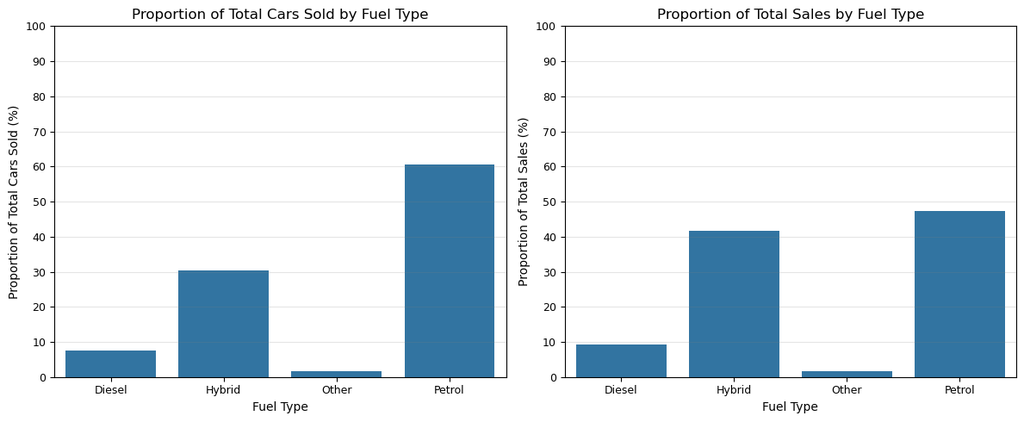

```python
#Visualize the number of cars sold & total sales per 'fuelType' as proportions of the total # cars sold & total sales
fig, axes = plt.subplots(ncols=2, figsize=(12,5))

#Total cars sold
ax1 = sns.barplot(data=FT_counts_sales.sort_values('fuelType'), x='fuelType', y='prop of total cars sold (%)', ax=axes[0])
#Total sales
ax2 = sns.barplot(data=FT_counts_sales.sort_values('fuelType'), x='fuelType', y='prop total sales (%)', ax=axes[1])

#edit plot details
for k, v in {'Proportion of Total Cars Sold by Fuel Type':[0, 'Proportion of Total Cars Sold (%)'],
             'Proportion of Total Sales by Fuel Type':[1, 'Proportion of Total Sales (%)']}.items():
    plt.sca(axes[v[0]])
    plt.title(k)
    plt.xlabel('Fuel Type')
    plt.xticks(fontsize=9)
    axes[v[0]].set(ylim=(0,100))
    plt.ylabel(v[1])
    plt.yticks(fontsize=9, ticks=range(0,101,10))
    plt.grid(axis='y',alpha=0.2,color='gray')
    plt.tight_layout();

#save the figure
plt.savefig('FT_props_nums_&_sales.png')
```

The two figures above illustrate the percentage of used cars sold by *Discount Motors* that each fuel type has accounted for over the last six months in terms of total cars sold & total sales respectively. The values along both of the vertical axes span from zero to 100 percent. It is assumed that electric vehicles associate with the "Other" fuel type.

##### Number of Cars Sold

As observed earlier, *Discount Motors* has relied on petrol-fuelled cars the most in recent months when it comes to the number of used cars that they've sold. Hybrid vehicles also account for a sizable proportion of the cars that the company has sold, whereas the diesel & "Other" fuel-type groups account for less than 10% of the total number of cars sold.  
If *Discount Motors* is wanting to sell more hybrid & electric cars in the coming years, then it might come at a cost to the number of petrol-based cars that they obtain & sell to customers. Moreover, given that hybrid & electric vehicles are generally newer than diesel & petrol cars, then the company might see the average age of their cars decrease. Hopefully the upcoming legislation issued by the UK regarding cars & emissions in 2030 naturally pushes more customers to become more interested & buy more hybrids & EV's. This will likely result in a greater demand for such cars which could then lead to an increase in the number of such cars sold by *Discount Motors*.

If the company continues to monitor this metric & react to it accordingly to help meet their goals, then it's important that these proportions for the hybrid & "Other" fuel-type groups of used cars increase in the coming years, particularly the closer to 2030. If the automotive market is restricted by what kinds of cars people can use on the road, then the demand for such cars will change as a result. To be best prepared for such changes, it is likely that *Discount Motors* will want to be selling more hybrid & electric vehicles than any other fuel type in the period leading up to 2030. Otherwise, the company could be forced to make significant changes in order to react to the changing demands of customers whilst also remaining competitive & profitable.

Such a process could be achieved more smoothly by setting targets at consistent intervals in the period leading up to 2030, which is when the most significant changes in the market are most likely to occur. In the last six months, of the total number of used cars sold by *Discount Motors*, about 30% & 1.6% of them were hybrid & electric vehicles respectively--about 20 used hybrids were sold for every used EV in this period. If the company wants a certain proportion of the cars they sell to be of these types by 2030, then they could set yearly or even monthly targets to reach this goal.

For example, if *Discount Motors* wants half of the vehicles that they sell in 2030 to be hybrids & electric vehicles, then they could establish yearly targets for each of the two groups as listed below. The data on the left assumes that the contributions of each group increases linearly year over year. The data on the right keeps the relevant proportion between the two groups observed in the last six months, which was 20 used hybrids sold for every one used EV sold.  
The company could play with these numbers as they wish depending on various factors such as how easy it is to acquire & sell hybrids & EV's, or how often they sell them. For example, if customers begin to purchase significantly more used electric vehicles in the next six months, then the company would likely want to obtain more of these cars & not as many hybrids.

- Note that at the time of this project, the date is around September, 2025.

[figure not shown]

##### Total Sales

To help see a change in the number of cars sold by fuel type, *Discount Motors* could alter their selling prices of each group. Over the last six months, the proportions of total sales that each of the four fuel groups contributed were relatively similar to those of the total numbers of cars sold. The main difference is that the proportions of sales accounted for by hybrid & petrol vehicles are much more similar. While *Discount Motors* sold about twice as many petrol-based cars than they did hybrids, the sales from these petrol-based cars only accounted for about 5.5% more in terms of total sales than that from hybrids. This simply indicates that on average, used hybrid vehicles were typically more expensive than used petrol vehicles.  
For electric vehicles, the proportions across the two metrics were essentially identical.

While there are many factors that can influence the price of a used car, in order to sell more of a certain type, one strategy involves lowering prices. Theoretically, for any product, there should be a price that optimizes the amount of sales (& the number of cars sold) that are yielded. Perhaps if *Discount Motors* slightly lowered the prices of their hybrid & electric vehicles, it might result in more of these cars being sold.  
On the other hand, the company could also increase the prices of petrol & diesel cars--which are less environmentally friendly--in order to indirectly encourage customers to consider buying hybrids or EV's. While this could result in less sales from petrol & diesel cars, it could lead to a greater number of hybrids & EV's being sold which would naturally yield more profits from these groups of cars.

Regarding total sales in relation to their objective of selling more hybrid & electric vehicles, this metric is heavily reliant on the number of cars that they sell across each group. The sales quantities will help to inform them as to how profitable their changes may or may not be. If the company manages to sell more hybrids & EV's in the coming years but they see a dip in their total sales, this could inform them that they need to make additional changes like altering prices.

- Over the last six months, *Discount Motors* has sold 6,738 used cars that yielded about £84,375,000 in sales.

Up to this point, one of the most decisive variables when it comes to hybrids/EV's versus other types of cars pertains to a car's road tax. Given that it depends on a car's emission & age, it is generally smaller for hybrid & electric vehicles. In the **Exploratory Data Analysis** section, it was observed that the typical road tax for used hybrid vehicles sold over the last six months was significantly smaller than for any of the other three fuel-type subgroups. While the typical road tax of electric vehicles was still sizably greater than for hybrids, there is definitely more optimism that they will decrease in the coming years, particularly in comparison to cars that produce emissions like petrol, diesel, & even hybrid cars to an extent.

With this context, customers will theoretically be more interested in vehicles with a small road tax. Therefore, *Discount Motors* could get more sales opportunities the more of these cars that they have. As such, a relevant metric could monitor the share of cars that they sell or have based on a range of road tax values. Of the 6,700-odd cars that the company sold in the last six months, the average & median road tax was about £95 & £135 respectively. About two-fifths of these vehicles had a road tax of £30 or less. This could be a convenient starting point to evaluate this metric.  
In summary, to sell more hybrids & electric vehicles, it would be more advantageous for the company if most of the cars that they sell have a relatively small road tax (<= £30).

```python
#Want to split the data into 2 groups: cars whose road tax is <= £30 & > £30

# <= £30
#Obtain # cars sold per 'fuelType'
num_FT_30und = df[df.tax <= 30].fuelType.value_counts(dropna=False).sort_index().reset_index().rename(
    columns={'count':'# cars sold'})
#Obtain proportions of total cars solds per 'fuelType'
prop_FT_30und = df[df.tax <= 30].fuelType.value_counts(dropna=False, normalize=True).reset_index().rename(
                columns={'proportion':'prop of cars sold'})
#Change the proportion to a percentage
prop_FT_30und['prop of cars sold (%)'] = np.round(100*prop_FT_30und['prop of cars sold'], 3)
#Merge the datasets
num_prop_FT_30und = num_FT_30und.merge(prop_FT_30und, on='fuelType')
#Add a variable indicating the road tax range
num_prop_FT_30und['road_tax_range'] = '<= £30'


# > £30
num_FT_ov30 = df[df.tax > 30].fuelType.value_counts(dropna=False).sort_index().reset_index().rename(
    columns={'count':'# cars sold'})
#Obtain # cars sold per 'fuelType'
num_FT_ov30 = df[df.tax > 30].fuelType.value_counts(dropna=False).sort_index().reset_index().rename(
    columns={'count':'# cars sold'})
#Obtain proportions of total cars solds per 'fuelType'
prop_FT_ov30 = df[df.tax > 30].fuelType.value_counts(dropna=False, normalize=True).reset_index().rename(
                columns={'proportion':'prop of cars sold'})
#Change the proportion to a percentage
prop_FT_ov30['prop of cars sold (%)'] = np.round(100*prop_FT_ov30['prop of cars sold'], 3)
#Merge the datasets
num_prop_FT_ov30 = num_FT_ov30.merge(prop_FT_ov30, on='fuelType')
#Add a variable indicating the road tax range
num_prop_FT_ov30['road_tax_range'] = '> £30'


#Merge the 2 datasets
RT_FT_counts = pd.concat([num_prop_FT_30und, num_prop_FT_ov30], axis=0).reset_index(drop=True)
#Reorganize columns
RT_FT_counts = RT_FT_counts[['fuelType','road_tax_range','# cars sold','prop of cars sold','prop of cars sold (%)']]
#display(RT_FT_counts)
```

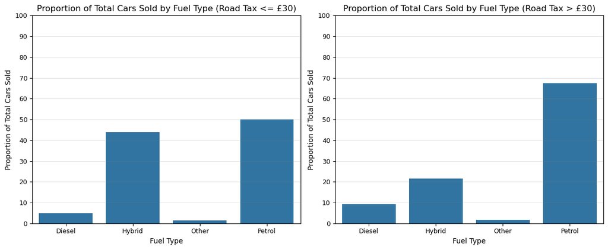

```python
#Visualize the number of cars sold per 'fuelType' as proportions of the total # cars sold & total sales per road-tax group
fig, axes = plt.subplots(ncols=2, figsize=(12,5))

#Road tax <= £30
ax1 = sns.barplot(data=RT_FT_counts[RT_FT_counts['road_tax_range'] == '<= £30'], x='fuelType', y='prop of cars sold (%)',
                  ax=axes[0])
#Road tax > £30
ax2 = sns.barplot(data=RT_FT_counts[RT_FT_counts['road_tax_range'] == '> £30'], x='fuelType', y='prop of cars sold (%)',
                  ax=axes[1])

#edit plot details
for k, v in {'Proportion of Total Cars Sold by Fuel Type (Road Tax <= £30)':[0],
             'Proportion of Total Cars Sold by Fuel Type (Road Tax > £30)':[1]}.items():
    plt.sca(axes[v[0]])
    plt.title(k)
    plt.xlabel('Fuel Type')
    plt.xticks(fontsize=9)
    axes[v[0]].set(ylim=(0,100))
    plt.ylabel('Proportion of Total Cars Sold')
    plt.yticks(fontsize=9, ticks=range(0,101,10))
    plt.grid(axis='y',alpha=0.2,color='gray')
    plt.tight_layout();

#save the figure
plt.savefig('FT_RT30_props.png')
```

The figures above depict the proportions of cars sold by *Discount Motors* in the last six months according to their fuel type. The left-side plot pertains to cars whose road tax was £30 or less, whereas the right-side plot corresponds to cars whose road tax was greater than £30. The two groups account for 2,653 & 4,085 used cars respectively. It is assumed that the "Other" fuel type accounts for electric vehicles. The vertical axes are proportions, so they range between zero & 100 percent.

These group levels observed here are similar to those observed throughout the project. Petrol & hybrid vehicles account for the largest slices, whereas electric vehicles occupy the smallest one. Nonetheless, there are some positive signs in these two plots in regard to the goals that the company have established in wanting to sell more hybrid & electric vehicles in the coming years.  
In the group with a road tax of £30 or less:

- Petrol & hybrid vehicles account for the significant majority of the cars sold. These two groups differ by about six percent, which is better than some of the more lopsided differences that have been seen previously.
- The more that hybrid & electric vehicles account for this group of cars, the more likely it becomes that they will be more appealing to customers, particularly those for whom the road-tax variable is a big factor in their decision-making process in purchasing a used car.
- In the coming years, the company will want the proportions of hybrid & electric vehicles to increase & eventually account for the majority of cars with a road tax less than £30.

In the group with a road tax greater than £30:

- Petrol vehicles account for significant majority of these sold cars. Hybrid & electric vehicles only account for 23% of these cars.
- In contrast to the <= £30 road-tax group, the company will want the proportions of hybrids & EV's to decrease & account for as small a minority of these cars as possible. If a small number of these cars that are sold by *Discount Motors* have a large road tax, then it indicates that most of them have a small road tax which makes them more appealing to customers.

Similarly to metrics previously discussed regarding inventory shares of used cars, the company can establish targets in the coming years leading up to 2030 that can help prepare the company to face whatever challenges & changes the automotive market may experience once the new legislation regarding automotive emissions goes into effect. It is expected that most people will want to invest in used hybrids & EV's come 2030, so if the company is already selling a sigificant number of such cars by then, then they will find these changes less tumultuous. Not to mention, they will likely be more competitive in the new market because their preparation will help them adapt swiftly to new customer interests & demands.

The proportion of cars sold in the last six months with a road tax of £30 or less that were hybrids is about 44%. The company could set a goal of 50% for this metric by 2030 & in the coming years, they could set goals that incrementall lead up to this value over time.  
A similar process can be done with electric vehicles, which accounted for about 1.3% of these cars in the last six months. If the company increases this number by one percent each year, then this proportion could reach six percent come 2030.

Ultimately, the company should set goals that will help them to obtain profits, increase their competitiveness in the market, appeal to customers, & encourage greater usage of environmentally-friendly vehicles. Some flexibility in these goals should also be considered because the ultimate direction of the automotive market is not set in stone. Perhaps the transition to hybrid & electric vehicles takes longer than expected, or maybe the UK government makes amendments to this legislation set to come into effect in 2030.

## Part III - Conclusions

This section explored how *Discount Motors* could use metrics to monitor their main problems & goals. The data was also used to estimate initial values for such metrics & provide possible targets to aim for in the future. Recall that a main priority was to sell more hybrid & electric vehicles in the coming years.

One general metric was evaluated from three perspectives. It pertained to the proportions of sold cars that each of the four fuel-type groups accounted for based on the last six months of data. Firstly, this metric was examined in terms of pure numbers; what percentage of cars sold did hybrids account for versus other types. Additionally, these proportions were directly compared to the proportions of sales that each fuel-type group accounted for.  
Through analyzing these quantities, it equips the company with knowledge regarding how they are achieving their profits. Given the goal of wanting to sell more hybrids & electric vehicles, this data could provide context as to how many they've sold recently. From there, they could set targets for the future that could help them accomplish their goals & also prepare for the potential of significant changes in the automotive market with the legislation established in the UK set to come into effect in 2030.

Through analyses of these first two areas over the last six months' worth of data, the following was determined.

- *Discount Motors* relied on petrol-based vehicles the most in terms of the number of cars they sold, but hybrid vehicles accounted for a sizable portion as well. About two petrol-based vehicles were sold for every used hybrid vehicle sold. Electric vehicles occupied the smallest slice across the four subgroups in this respect.
- In terms of total sales, the gap between petrol & hybrid vehicles was significantly smaller, but the former was still the dominant group. Once more, electric vehicles accounted for a very small portion.

To achieve their goals, *Discount Motors* will want to make adjustments that lead to an increase of the proportions of hybrid & electric vehicles sold in the coming years. A couple of examples were provided that lay out yearly targets that the company could aim for in terms of the proportion of used hybrids & electric vehicles that they sell in the future.  
Naturally, changes in total sales accounted for by hybrids & electric vehicles will occur as a result of these adjustments. These quantities regarding total sales can help to inform the company as to how profitable their changes may or may not be. If the company manages to sell more hybrids & EV's in the coming years but they see a dip in their total sales, this could inform them that they need to make additional changes like altering prices.

- Petrol cars account for about half of the sold cars with a road tax of £30 or less, whereas hybrids account for about 45%. For cars with a greater road tax, petrol-based cars dominate while hybrids only account for about 20%. Electric vehicles account for very small portions across both subgroups.
- In the coming years, the company will want the proportions of hybrid & electric vehicles to increase & eventually account for the majority of cars with a road tax less than £30.

# Part IV - Summary & Recommendations

**Final summary including recommendations that the business should undertake.**

This report sought to understand the last six months' of data of used cars sales to understand how it could be used to promote certain types of vehicles in the future. More specifically, by examining prices, sales data, & other characteristics of different types of used cars, this report was able to gather meaningful information that *Discount Motors* could use to achieve their goal of wanting to sell more hybrid & electric vehicles in the near future.

The first detail that stood out in analyses was that in the last six months, *Discount Motors* has relied on selling many petrol vehicles; they account for 60% of the cars that they've sold, which is about twice the number of hybrids--the second largest group. If the company wants to sell more hybrid & electric vehicles, then they will likely have to sacrifice the number of petrol cars that they house & sell. While this sounds straightforward, this will likely be more difficult in practice because there is probably a large demographic that goes to *Discount Motors* for used, petrol-based vehicles. The bigger challenge lies in persuading these people to invest in or at least begin to consider more environmentally-friendly vehicles like hybrids & EV's.

As such, *Discount Motors* should also do some research regarding the general differences & benefits of hybrids & EV's versus petrol- & diesel-engined vehicles. In doing so, they will not only be more knowledgeable in understanding the pros & cons of each group, but they will also be better prepared to answer questions that customers may have.  
Moreover, with the new legislation established by the UK regarding vehicles & their emissions, which is set to come into effect in 2030, the automotive market could see a significant shift in what kinds of cars are used & how they are valued by the general population. Therefore, having a greater understanding of these vehicles will only be a benefit to the company.

One variable in the data that highlights a significant benefit of hybrids & electric vehicles versus less environmentally-friendly cars--diesel & petrol cars--pertains to their road taxes. In the **Exploratory Data Analysis** section (section II), it was discovered that of the used cars sold in the last six months, hybrid vehicles typically had a road tax of £20. Conversely, electric, diesel-based, & petrol-based vehicles had a typical road tax of £140, £145, & £145 respectively. Moreover, the ranges of road taxes of hybrid & electric vehicles were noticeably lower than they were for the latter two types of cars.  
This is perhaps the most striking finding observed in this report, & it should definitely be used when advertising hybrids & EV's.

- Although, the road taxes of electric vehicles were considerably higher than for hybrids, this group of cars has the most optimism regarding this variable because electric vehicles are the cleanest of the four groups when it comes to emissions. Moreover, if the UK wants to place greater emphasis on lowering emissions from automotive vehicles, making electric vehicles more affordable will make a big impact.
  - Moreover, in the past six months, *Discount Motors* has only sold 105 EV's, so obtaining & selling more of them will help to garner more insights as to how they can be optimally marketed.

Other analyses in **Section II** examined cars' average prices & fuel consumption & efficiency levels based on the year that they were registered.

- **Average price vs registration year:**
  - The overall trend of average prices indicated that newer models are typically more expensive. Of cars made in the last three years (2018-2020), their average price was considerably higher than the year before (by about 25% on average). As such, there could be an optimal "value" for both the customer & the seller that compromises between a car's age & its selling price. The younger the car, it will have more long-term value but will probably be more expensive; however, for older cars, it may be cheaper, but it may have more problems & less long-term value.

    > As such, *Discount Motors* might want to place a greater emphasis on advertising hybrids & electric cars which are registered between three to five years prior to the current date. This way, the company can still sell them at a profitable cost that isn't too high such that it quickly turns away most customers. For the customer, they get a reasonably priced car that can give them a desirable long-term value.
    > - Given the small number of electric vehicles that the company has sold in the last six months, it makes them more unpredictable. Moreover, these cars are still fairly new to the automotive industry, so customers will likely prefer to have a younger model because they are less likely to experience problems. *Discount Motors* could take advantage of this by advertising electric vehicles made more recently than hybrids. Instead of 3-5 years old, this "optimal age" for EV's may be closer to 2-4 years.
- **Fuel consumption/efficiency vs registration year:**
  - The data was analyzed across two groups: cars registered between 1998-2017 & those registered in 2018-2020.
  - The typical fuel efficiency level declined between the older & younger generations across all four of the subgroups of cars; however, this decrease was sizably smaller for used hybrid vehicles.
  - Also, hybrid vehicles saw the greatest fuel efficiency in both registration periods across the four subgroups. So, the fuel efficiency of hybrid vehicles is the most optimistic for the immediate future. Electric vehicles have relatively competitive values in this metric, but they are a clear step behind compared to hybrids.

    > This data is another example of an advantage used hybrid vehicles possess over the other types of cars that *Discount Motors* has offered recently.

In **Section III**, the proportions of cars sold based on their fuel type & road tax were evaluated. The data was split into two groups: cars with a road tax of £30 or less & those with a higher road tax. Naturally, the group with the lower road tax, which accounted for about 40% of the cars sold, should be more appealing to customers because they will cost less over time.

- For cars with a relatively low road tax (<= £30), petrol-based cars are still the dominant group, but they only accounted for about five percent more of these cars than the hybrid group. While this is an encouraging starting point, the company would do well to increase the proportion of hybrids & EV's in this group if they want to sell more of these cars over time. This could be done by continuing to advertise their advantages including how much lower the road tax is for hybrids compared to petrol-based vehicles.
- For cars with a greater road tax (> £30), hybrids only accounted for about 20% of the cars sold.

  > If the company wants to sell more hybrids & electric vehicles, then they could consider obtaining & advertising more petrol & diesel cars that have high road taxes than they have recently. The more prominent the benefit of hybrids & EV's in terms of road taxes, the more appealing they will become to customers.

In summary, the main recommendations for the marketing team include:

- Explore & research the primary differences between hybrids & electric vehicles versus diesel & petrol vehicles.
- Advertise hybrids & EV's more than any other kind of car. In particular:
  - Emphasize the eco-friendly nature of these cars compared to diesel & petrol cars. Selling cars on the premise of being "eco-friendly" relies on there being customers that are aware & interested in minimizing their ecological footprint.
  - Emphasize the lower road taxes & greater fuel efficiencies of these cars compared to diesel & petrol cars.
  - Prioritize used cars that are not too young or too old (the "Goldilocks range"). For hybrids, cars registered 3-5 years prior are likely the most optimal. For EV's, cars registered 2-4 years prior are likely the most optimal.
- Slowly shift the inventory of diesel & petrol vehicles so that there are less appealing options to customers.
  - Obtain & house fewer diesel & petrol vehicles with: a small road tax, a low fuel consumption (high efficiency), older models, underpriced cars, etc.
- Continue to house & sell reliable hybrid & electric vehicles at a profitable yet affordable price that is beneficial for both the company & customer. Place greater emphasis on models with less mechanical & technical issues, & those with a small road tax.
  - Between hybrids & electric vehicles, be more patient & cautious with the latter. Since the company only sold a handful of them (relatively speaking) over the last six months, there is less representative data for them. The more EV's that are sold will help paint a clearer picture in terms of how they can be marketed optimally going forward.
- Monitor the metrics established in **Section III**; proportions of hybrids & EV's sold versus diesel & petrol cars.
- Improve the data collection method to allow for more efficient analyses.
  - For example, there were about 100 used cars sold with the fuel type "Other" in the last six months, but the meaning of this fuel type is unclear.
  - More variables can be created & tracked to analyze more characteristics about used cars & their potential relationships with other variables.
- Remain flexible, but be prepared to make changes if necessary. Also, monitor the progression of the 2030 mandate issued by the UK (regarding cars & their emissions) along with similar legislative measures pertaining to the automotive market.